# Elaborato per Network Data Analysis: il dataset Marvel Comic Characters Partnerships

# Descrizione di base della rete

Il dataset è stato reperito al seguente link:

https://www.kaggle.com/datasets/trnguyen1510/the-marvel-comic-characters-partnerships

I dati sono una **rete non pesata**, contenenti **350 nodi e 346 archi**, dove ogni **nodo** rappresenta un **personaggio** dell’universo Marvel e ogni **arco** rappresenta l’esistenza di una **“interazione stretta”** (*partnership*) tra due personaggi *stabilita sui link presenti nelle pagine Wikipedia di ciascun personaggio*, ricorrendo alla sezione “partnerships” presente in molte (ma non in tutte) le **infobox** riportate a lato della pagina.

Non era inizialmente chiaro se il grafo andasse considerato orientato o meno: il dataset è infatti fornito in due file csv separati, uno con i nodi e l’altro per gli archi, contenente la lista delle coppie di nodi indicati come `source` e `target`. Si nota tuttavia che, **se trattato come grafo direzionato, la sua reciprocità vale 0:** ciò si scontra con l’evidenza sperimentale di almeno 4 collaborazioni documentate invece come reciproche nelle corrispondenti pagine Wikipedia, ossia

- `Spider-Man` (https://en.wikipedia.org/wiki/Spider-Man) & `Black Cat` (https://en.wikipedia.org/wiki/Black_Cat_(Marvel_Comics))
- `Spider-Man` (https://en.wikipedia.org/wiki/Spider-Man) & `Spider-Man (Miles Morales)` (https://en.wikipedia.org/wiki/Miles_Morales)
- `Captain America` (https://en.wikipedia.org/wiki/Captain_America) & `Bucky Barnes` (https://en.wikipedia.org/wiki/Bucky_Barnes)
- `Iron Man` (https://en.wikipedia.org/wiki/Iron_Man) & `War Machine` (https://en.wikipedia.org/wiki/War_Machine)

Ad eccezione di `Spider-Man` & `Spider-Man (Miles Morales)` (essendo Miles Morales un personaggio piuttosto recente, apparso nel 2011), le altre connessioni sono da ritenere “storiche” (alcune risalenti alla *golden age*) ed è poco palusibile che non fossero già documentate correttamente nel 2018, anno di creazione del dataset. Pertanto, **il dataset viene qui considerato come un grafo non direzionato affinché rifletta correttamente i legami di partnerships,** per riuscire a dare un’intepretazione “sensata” ai risultati trovati sul grafo.

L’interpretazione non orientata del grafo trova conferma nel repository https://networks.skewed.de/net/marvel_partnerships#fnref:icon dove viene classificato come *Undirected*.

Il dataset contiene anche un **attributo categoriale per ciascun nodo**, dividendo i personaggi in **eroi** (0), **cattivi** (1) e personaggi “grigi” altrimenti detti **antieroi** (2); questi ultimi possiedono qualità sia degli eroi che dei cattivi, ossia personaggi solitamente privi di qualità eroiche che a volte compiono azioni moralmente corrette, ma agendo principalmente per interesse personale o in modi che sfidano i codici etici convenzionali.

### Osservazione

Il dataset potrebbe essere ricondotto ad una situazione reale immaginando che i personaggi Marvel siano gli **impiegati di un’azienda** afferenti principalmente a **due reparti distinti** (eroi e cattivi), magri in competizione, più qualche altra figura con un ruolo meno strutturato (gli antieroi), e che si voglia studiare le **interazioni strette tra i vari dipendenti.**

## Caricamento e preparazione dei dati

Il dataset scaricato è organizzato in due distinti file: `nodes.csv` e `edges.csv`:

- in `nodes.csv` sono presenti la colonna `group` (la natura del personaggio), `id` (il nome del personaggio) e `size` (il numero di connessioni che ciascun personaggio ha con gli altri del dataset).
- il file `edges.csv` contiene invece la colonna `source` e la colonna `target` indicanti il verso *presunto* della relazione tra i personaggi riportati nelle due colonne.

Si procede al loro caricamento in R e alla semplificazione di alcuni nomi, cercando laddove possibile di limitare la lunghezza di quelli più prolissi, in particolare rimuovendo le indicazioni tra parentesi come in `'Cyclone (Marvel Comics)'`).

```r
rm(list=ls())
setwd("C:/Users/dario/Documents/Projects/Master/Networks/")

library(igraph)

myseed = 6174

# lettura file csv
nodes_data = read.csv('nodes.csv')
edges_data = read.csv('edges.csv')

# Semplificazione dei nomi lunghi
orig_char = c('Blackout (Lilin)',
              'Blackout (Marcus Daniels)',
              'Hawkeye (Kate Bishop)',
              'Iron Man (Ultimate Marvel character)',
              'Spider-Man (Miles Morales)',
              'Spider-Woman (Gwen Stacy)',
              'Spider-Woman (Jessica Drew)'
)
new_char = c('Blackout L.',
             'Blackout M.D.',
             'Hawkeye K.B.',
             'Iron Man U.M.c.',
             'Spider-Man M.M.',
             'Spider-Woman G.S.',
             'Spider-Woman J.D.'
)
for (n in 1:length(orig_char))
{
   nodes_data$id[nodes_data$id == orig_char[n]] = new_char[n]
   edges_data$source[edges_data$source == orig_char[n]] = new_char[n]
   edges_data$target[edges_data$target == orig_char[n]] = new_char[n]
}
# rimozione del contenuto tra parentesi
nodes_data$id = gsub("\\s*\\([^\\)]+\\)", "", nodes_data$id)
edges_data$source = gsub("\\s*\\([^\\)]+\\)", "", edges_data$source)
edges_data$target = gsub("\\s*\\([^\\)]+\\)", "", edges_data$target)

# converto i codici 0,1,2 in group in una versione testuale
group = nodes_data$group
nodes_data$group = NULL #rimuovo la colonna group, crea problemi a graph_from_data_frame
group_labels = c("hero", "villain", "antihero")
nodes_data$category = as.factor(group_labels[group + 1]) #reinserisco group come variabile categorica

# associo dei colori alle categorie
group_colors = c('darkgray', 'lightblue', 'lightsalmon')
group_colors_borders = c(c('gray50', 'lightblue3', 'lightsalmon3'))
# group_colors = c('lightblue', 'lightsalmon', 'darkgray')
# group_colors_borders = c(c('lightblue3', 'lightsalmon3', 'gray50'))


node_colors = group_colors[as.numeric(nodes_data$category)]
border_colors = group_colors_borders[as.numeric(nodes_data$category)]
```

## Creazione grafo non direzionato

[figure not shown]

```r
marvel_Ugraph = graph_from_data_frame(d=edges_data, vertices=nodes_data, directed=F)

set.seed(myseed)
#my_layout = layout_with_fr#(marvel_Ugraph, start.temp = 100, niter=3000)
layout_full <- layout_with_fr(marvel_Ugraph)

conn = components(marvel_Ugraph)
id_maxconn = which(conn$csize== max(conn$csize))
nodes_maxconn = which(conn$membership == id_maxconn)
edges_maxconn <- E(marvel_Ugraph)[.from(nodes_maxconn) & .to(nodes_maxconn)]

V(marvel_Ugraph)$name = nodes_data$id
V(marvel_Ugraph)$category = nodes_data$category
V(marvel_Ugraph)$size = 3.5
V(marvel_Ugraph)$color = node_colors
V(marvel_Ugraph)$frame.color = border_colors
V(marvel_Ugraph)$label.cex = 0.3
V(marvel_Ugraph)$label.family = 'sans'
V(marvel_Ugraph)$label.color='black'

E(marvel_Ugraph)$width = 1#0.9
E(marvel_Ugraph)[edges_maxconn]$width= 1.2
E(marvel_Ugraph)$color = "darkolivegreen3"
E(marvel_Ugraph)[edges_maxconn]$color = "darkolivegreen"

par(mar = c(0, 0, 0, 0))
set.seed(myseed)
plot(marvel_Ugraph,
     layout=layout_full,
     vertex.color= 'cornsilk2', #'burlywood1',
     vertex.frame.color = 'cornsilk3', #'burlywood3',
     vertex.frame.width = 0.5,
     edge.width = 0.5,
)
```

```r
set.seed(myseed)
plot(marvel_Ugraph,
     layout=layout_full,
     vertex.label = NA,
)
legend('topright', legend = levels(nodes_data$category), fill = group_colors, bty = 'n')
```

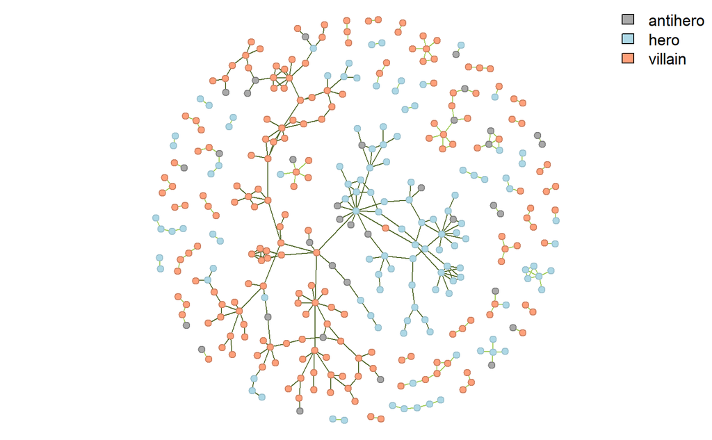

```r
par(mar=c(5,4,4,2)+0.1)
```

```r
marvel_Umaxconn = induced_subgraph(marvel_Ugraph, vids = nodes_maxconn, impl='create_from_scratch')
```

La rete presenta una grossa componente connessa, e poi altri sottografi connessi molto più piccoli, riconducibili probabilmente a personaggi minori o presenti in serie poco soggette a *cross-over*.

## Analisi descrittiva a livello di rete

### Densità

La densità $\rho \in [0,1]$ può essere considerata una stima della **probabilità di osservare un arco tra nodi selezionati casualmente.**
$$\begin{equation}
\rho = \frac{\text{# di archi}}{\text{max # di archi}} \in [0,1]
\end{equation}$$

### Reciprocità

Nel caso di una **rete direzionata** l’indice di reciprocità $R$ punta a quantificare quanto sia forte la **tendenza a ricambiare una relazione:** è definita come la frazione $R$ di legami reciproci
$$\begin{equation*}
R = \frac{\text{# di archi reciproci}}{\text{# di archi}} \in [0,1]
\end{equation*}$$

- R = 0 implica che tutte le relazioni osservate tra i nodi nella rete non sono reciproche.
- R = 1 implica che tutte le relazioni osservate tra i nodi nella rete sono reciproche (in una rete non direzionata, tale indice vale ovviamente sempre 1).

### Transitività

Nell’ambito delle **reti non direzionate,** la transitivà indica la **tendenza a formare legami a 3 tre** tra i nodi, ed è misurabile attraverso il coefficiente di transitività o di *clustering* $C$
$$\begin{equation*}
C = \frac{\text{# di cammini $chiusi$ di lunghezza 2}}{\text{# di
cammini di lunghezza 2}} \in [0,1]
\end{equation*}$$

### Assortatività

- L’**assortatività** o *omofilia* modella la possibilità di osservare legami tra nodi che sono simili tra loro piuttosto che tra quelli che non lo sono.
- La **dissassortatività** o *eterofilia* indica lo schema opposto

Limitando il concetto ad una **rete non direzionata (non pesata)** con $m$ archi $\{u_{ij}\} \in \{0,1\}$, e con **attributi nodali nominali** (*eroi*, *cattivi* e *antieroi*) $c_i$, l’**indice di assortatività** $r$ è definito attraverso la **modularità** $Q$, che confronta il **numero di archi all’interno delle comunità** con quello atteso in una **rete casuale**
$$\begin{align*}
r &= \frac{Q}{Q_{\max}} \in [-1,1]\\
Q &= \frac{1}{2m} \sum_{ij} u_{ij} - \frac{k_i k_j}{2m} \delta(c_i,
c_j)\\
\delta(c_i,c_j) &= \begin{cases} 1 & c_i=c_j \\ 0 & c_i \neq
c_j\end{cases}
\end{align*}$$
essendo $k_n$ il **grado** (cioè il # di archi incidenti) del nodo $n$.

In R è disponible la funzione *assortativity_nominal()* che calcola $r$ attraverso la **frazione $e_{ij}$ di archi che connettono i nodi di *tipo* $c_i$ e *tipo* $c_j$**:
$$\begin{align*}
r &= \frac{\sum_i e_{ii} -\sum_i a_i b_i}{1-\sum_i a_i b_i}\\
a_i &= \sum_j e_{ij} \\
b_j &= \sum_i e_{ij}
\end{align*}$$

```r
# grafo NON DIREZIONATO
rho_u = edge_density( marvel_Ugraph)
R_u = reciprocity(  marvel_Ugraph)
C_u = transitivity( marvel_Ugraph)
r_u = assortativity_nominal(marvel_Ugraph, V(marvel_Ugraph)$category)

rho_c = edge_density( marvel_Umaxconn)
R_c = reciprocity(  marvel_Umaxconn)
C_c = transitivity( marvel_Umaxconn)
r_c = assortativity_nominal(marvel_Umaxconn, V(marvel_Umaxconn)$category)

table_graph <- data.frame(
   "Whole" = c(rho_u, R_u, C_u, r_u),
   "Maxconn" = c(rho_c, R_c, C_c, r_c),
   row.names = c("Densità", "Reciprocità", "Transitività", "Assortatività")
)
table_graph$Whole = sprintf("%.3f", table_graph$Whole)
table_graph$Maxconn = sprintf("%.3f", table_graph$Maxconn)


(table_graph)
```

|  | Whole | Maxconn |
| --- | --- | --- |
| Densità | 0.006 | 0.014 |
| Reciprocità | 1.000 | 1.000 |
| Transitività | 0.219 | 0.216 |
| Assortatività | 0.626 | 0.671 |

#### Osservazioni

- la **densità** aumenta nel caso del sottografo massimamente connesso dato il minor numero di archi “mancanti” rispetto al grafo completo con tutte le altre componenti
- la **bassa transitività** in entrambi i casi riflette la natura dei legami definiti dal concetto di “partnerships”, trattandosi cioè di associazioni strette (tipo Iron-Man e War-Machine, che operano spesso in coppia) diverse dalle collaborazioni in team (tipo Avengers)
- l’**assortatività positiva** (non trascurabile, in quanto **superiore a 0.6** sia nel grafo completo che per il sottografo maggiormente connesso) riflette la natura dell’attributo, ed è indice che i cattivi si legano solitamente ad altri cattivi e i buoni ad altri buoni.

## Analisi descrittiva a livello di nodi

Ci concentriamo qui sulla **componente maggiormente connessa `marvel_Umaxconn`:** del grafo non direzionato `marvel_Ugraph` con archi $u_{ij} \in \{0,1\}$: questo sia perché gli altri sottografi sono relativi a personaggi o serie molto meno rilevanti nell’universo Marvel, sia perché si vuole confrontare in modo “equo” i tre diversi concetti di centralità di seguito definiti.

```r
set.seed(myseed)
indices_maxconn_in_ugraph = match(V(marvel_Umaxconn)$name, V(marvel_Ugraph)$name)
layout_maxconn = layout_full[indices_maxconn_in_ugraph, ]
set.seed(myseed)
par(mar = c(0, 0, 0, 0))
set.seed(myseed)
plot(
   marvel_Umaxconn,
   layout = layout_maxconn,
   edge.width = 0.5
)
legend('topright', legend = levels(nodes_data$category), fill = group_colors, bty = 'n')
```

[figure not shown]

```r
par(mar=c(5,4,4,2)+0.1)
```

### Degree Centrality (centralità di grado)

Il **grado** (degree) $\zeta_i^d$ o la *centralità di grado* di un nodo $i$ indica il **numero di legami che coinvolgono $i$**
$$\begin{equation*}
\zeta_i^d = \sum_{ij} u_{ij}
\end{equation*}$$
Per una rete con $n$ nodi, $\zeta_i^d \in [0,n-1]$

La sua versione normalizzata $\tilde\zeta_i^d$ è quindi definita come
$$\begin{equation*}
\tilde\zeta_i^d = \frac{\sum_{ij} u_{ij}}{n-1} \in [0,1]
\end{equation*}$$

**La centralità di grado fornisce informazioni sull’influenza diretta del nodo nella rete e sul suo accesso alle informazioni di prima mano**

```r
plot_centrality <- function(centr_norm, thr_q, scaleText=F)
{
   thr_norm = quantile(centr_norm, thr_q)
   print(thr_norm)
   nameoff = which(centr_norm<thr_norm)
   showname = V(marvel_Umaxconn)$name
   showname[nameoff] = NA

   cexText = 0.5
   if (scaleText==T)
      cexText = centr_norm*12

   par(mar=c(0,0,0,0))
   plot(marvel_Umaxconn,
        layout=layout_maxconn,
        vertex.size = centr_norm*22,
        vertex.label = showname,
        vertex.label.cex = cexText,#0.5,
        edge.width = 0.4
   )
   par(mar=c(5,4,4,2)+0.1)
}

deg = degree(marvel_Umaxconn)
deg_norm = degree(marvel_Umaxconn, normalized = T)

par(mar=c(4,4,3,0))
hist(deg_norm, freq=F, main='degree centrality', col='palegreen3', border='palegreen4')
grid(lty='solid', lwd=0.5, col='white', nx=NA, ny=NULL)
```

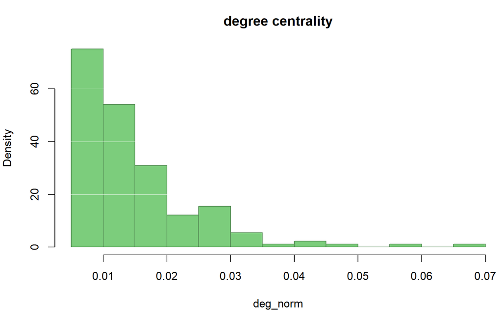

```r
par(mar=c(5,4,4,2)+0.1)
```

```
       95%
0.03333333
```

[figure not shown]

```r
thr_q = 0.95
plot_centrality(deg_norm, thr_q, T)
```

```r
ord = order(deg_norm, decreasing = T)
degrank = data.frame(name = V(marvel_Umaxconn)$name[ord], degree = deg[ord], degnorm=deg_norm[ord])
(degrank)
```

|  | name | degree | degnorm |
| --- | --- | --- | --- |
| Spider-Man | Spider-Man | 12 | 0.066666667 |
| Captain America | Captain America | 10 | 0.055555556 |
| Red Skull | Red Skull | 9 | 0.050000000 |
| Unicorn | Unicorn | 8 | 0.044444444 |
| Attuma | Attuma | 8 | 0.044444444 |
| Iron Fist | Iron Fist | 7 | 0.038888889 |
| Venom | Venom | 6 | 0.033333333 |
| Scarecrow | Scarecrow | 6 | 0.033333333 |
| Chameleon | Chameleon | 6 | 0.033333333 |
| Grim Reaper | Grim Reaper | 6 | 0.033333333 |

[output cut: 171 more lines]

### Closeness centrality (centralità di prossimità)

Per valutare la *prossimità* di un nodo rispetto agli altri nodi occorre prima introdurre introdurre la **farness** (*lontananza*) $l_i$ di un nodo
$$\begin{equation*}
l_i = \sum d_{ij}
\end{equation*}$$
essendo $d_{ij}$ la lunghezza del **cammino più breve** tra il nodo $i$ ed il nodo $j$.

La **closeness** $\zeta_i^c$ di un nodo $i$ vale
$$\begin{equation*}
\zeta_i = \frac{1}{l_i}
\end{equation*}$$

Poiché il massimo di $\zeta_i^c$ si verifica quando $i$ è connesso a tutti quanti gli altri nodi della rete (*configurazione a stella*), cioè $\zeta_{\max}^c = 1/\sum_{i \neq j} 1 = 1/(n-1)$, la closeness normalizzata $\tilde\zeta_i^c$ vale
$$\begin{equation*}
\tilde\zeta_i^c = \frac{\zeta_i^c}{\zeta_{\max}^c} = \frac{n-1}{l_i} \in
[0,1]
\end{equation*}$$

**La closeness è utilizzata per individuare nodi strategici per la trasmissione di informazioni: indica se un nodo ha un accesso rapido e diretto agli altri nodi**

#### Osservazione

Poiché in `marvel_Ugraph` non esiste sempre almeno un cammino tra tutte le coppie di nodi), **applichiamo il concetto di closeness centrality solo al sottografo connesso più numeroso.**

```r
clo = closeness(marvel_Umaxconn)
clo_norm = closeness(marvel_Umaxconn, normalized = T)

par(mar=c(4,4,3,0))
hist(clo_norm, freq=F, main='closeness centrality', col='palegreen3', border='palegreen4')
grid(lty='solid', lwd=0.5, col='white', nx=NA, ny=NULL)
```

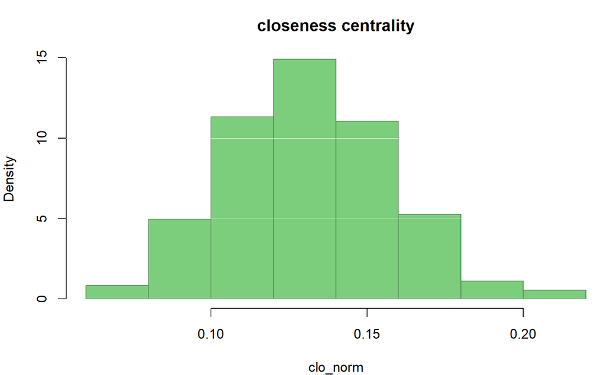

```r
par(mar=c(5,4,4,2)+0.1)
```

```
      95%
0.1727447
```

[figure not shown]

```r
plot_centrality(clo_norm, thr_q)
```

```r
ord = order(clo_norm, decreasing = T)
clorank = data.frame(name = V(marvel_Umaxconn)$name[ord], closeness = clo[ord], clonorm=clo_norm[ord])
(clorank)
```

|  | name | closeness | clonorm |
| --- | --- | --- | --- |
| Venom | Venom | 0.0011890606 | 0.21403092 |
| Doctor Doom | Doctor Doom | 0.0011547344 | 0.20785219 |
| Spider-Man | Spider-Man | 0.0011037528 | 0.19867550 |
| Puppet Master | Puppet Master | 0.0010515247 | 0.18927445 |
| Red Skull | Red Skull | 0.0010438413 | 0.18789144 |
| Enchantress | Enchantress | 0.0010090817 | 0.18163471 |
| Carnage | Carnage | 0.0009900990 | 0.17821782 |
| Eddie Brock | Eddie Brock | 0.0009881423 | 0.17786561 |
| Magneto | Magneto | 0.0009823183 | 0.17681729 |
| Wraith | Wraith | 0.0009596929 | 0.17274472 |

[output cut: 171 more lines]

### Betweenness centrality (centralità di intermediazione)

L’idea alla base della betweenness centrality è che un **nodo sia maggiormente centrale per una data rete quanto più si trova tra molti altri nodi.**

La betweenness $\zeta_i^b$ di un nodo $i$ è la **frazione dei cammini minimi che passano attraverso $i$**
$$\begin{align*}
\zeta_i^b &= \sum_{j>1} \sum_{k>j} \frac{n_{jk}^i}{g_{jk}}
\qquad \textsf{con}\\
\frac{n_{jk}^i}{g_{jk}} &= 0 \quad\textsf{se}\quad n_{jk}^i = g_{jk}
= 0 \\
n_{jk}^i &= \textsf{# di cammini minimi tra i nodi $j$ e $k$
passanti attraverso $i$}\\
g_{jk} &= \textsf{# di cammini minimi tra i nodi $j$ e $k$ in
totale}
\end{align*}$$

Poiché il massimo di $\zeta_i^b$ si verifica quando $i$ si trova su tutti i percorsi geodetici che collegano ogni coppia di altri nod, ossia si ha
$$\begin{equation}
n_{jk}^i=g_{jk}\enspace \forall\, (j,k) \quad \Rightarrow \quad
\zeta_{\max}^b = \sum_{j>i} \sum_{k>i} 1 = \frac{(n-1)(n-2)}{2}
\end{equation}$$
il valore normalizzato $\hat\zeta_i^b$ è definito come
$$\begin{equation}
\tilde\zeta_i^b = \frac{\zeta_i^b}{(n-1)(n-2)}
\end{equation}$$

**La betweenness centrality aiuta ad identificare nodi strategici o vulnerabili in una rete: indica quanto un vertice sia cruciale come “snodo” per i flussi di informazioni o connessioni nel grafo.**

#### Osservazione

Coinvolgendo di nuovo i cammini minimi, anche in questo caso, prendiamo qui in considerazione solo il sottografo connesso più numeroso.

```r
bet = betweenness(marvel_Umaxconn)
bet_norm = betweenness(marvel_Umaxconn, normalized = T)
par(mar=c(4,4,3,0))
hist(bet_norm, freq=F, main='betweenness centrality', col='palegreen3', border='palegreen4')
grid(lty='solid', lwd=0.5, col='white', nx=NA, ny=NULL)
```

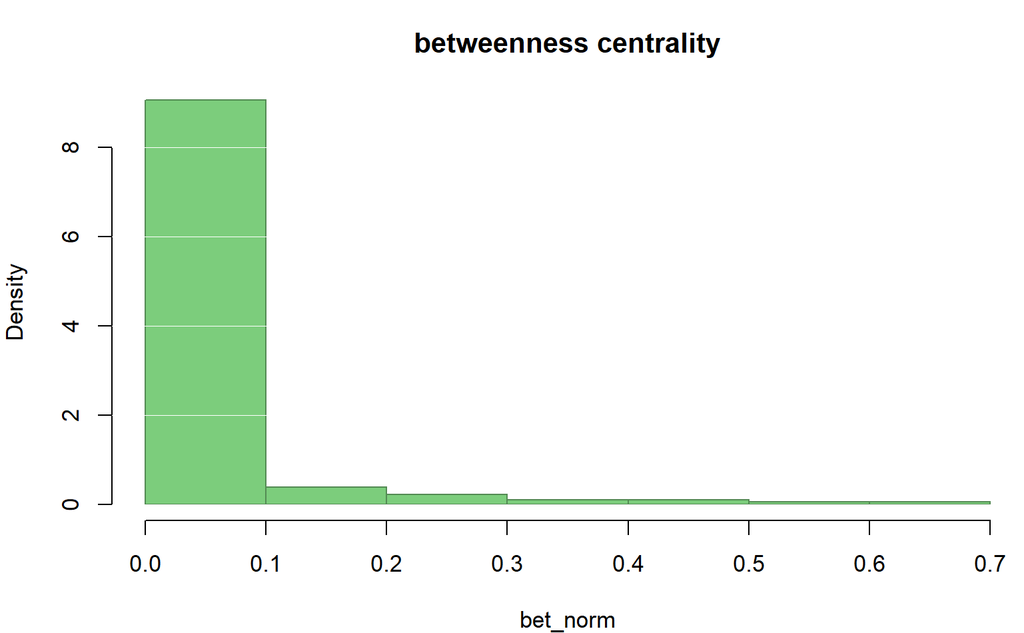

```r
par(mar=c(5,4,4,2)+0.1)
```

```
     95%
0.222843
```

[figure not shown]

```r
plot_centrality(bet_norm, thr_q)
```

```r
ord = order(bet_norm, decreasing = T)
betrank = data.frame(name = V(marvel_Umaxconn)$name[ord], betweenness = clo[ord], betnorm=bet_norm[ord])
(betrank)
```

|  | name | betweenness | betnorm |
| --- | --- | --- | --- |
| Venom | Venom | 0.0011890606 | 6.644631e-01 |
| Doctor Doom | Doctor Doom | 0.0011547344 | 5.653631e-01 |
| Spider-Man | Spider-Man | 0.0011037528 | 4.906425e-01 |
| Puppet Master | Puppet Master | 0.0010515247 | 4.010863e-01 |
| Krang | Krang | 0.0009541985 | 3.562384e-01 |
| Attuma | Attuma | 0.0008688097 | 3.328057e-01 |
| Red Ghost | Red Ghost | 0.0007886435 | 2.932961e-01 |
| Red Skull | Red Skull | 0.0010438413 | 2.869646e-01 |
| Enchantress | Enchantress | 0.0010090817 | 2.467412e-01 |
| Unicorn | Unicorn | 0.0007127584 | 2.228430e-01 |

[output cut: 171 more lines]

### Nodi importanti

```r
topnodes <- function(centr_norm, thr_q)
{
   thr_norm = quantile(centr_norm, thr_q)
   idon = which(centr_norm>=thr_norm)
   return(idon)
}

hc = quantile(clo_norm, thr_q)
hb = quantile(bet_norm, thr_q)

idtop_deg = topnodes(deg_norm, thr_q)
idtop_clo = topnodes(clo_norm, thr_q)
idtop_bet = topnodes(bet_norm, thr_q)

idtop = union(union(idtop_deg, idtop_clo), idtop_bet)
idxor = setdiff(union(idtop_deg, union(idtop_clo, idtop_bet)), intersect(idtop_deg, intersect(idtop_clo, idtop_bet)))
idbest = intersect(intersect(idtop_deg, idtop_clo), idtop_bet)

par(mar = c(4, 4, 2, 1))
scaldeg = 6
scores = data.frame(name =V(marvel_Umaxconn)$name, deg=deg, clo=clo_norm, bet=bet_norm)
plot(scores$bet, scores$clo,
     ylab = 'Closeness',
     xlab = 'Betweenness',
     main = 'Node centralities',
     xlim = c(0,0.9),
     cex = scores$deg/scaldeg,
     pch = 21,
     col = V(marvel_Umaxconn)$color,
     bg = "white",
     bty='n'
)
points(scores$bet[idtop_deg], scores$clo[idtop_deg], cex=scores$deg[idtop_deg]/scaldeg,
       pch = 21, col=V(marvel_Umaxconn)$color[idtop_deg], bg=V(marvel_Umaxconn)$color[idtop_deg])
```

```r
abline(h = hc, lty = 2)
abline(v = hb, lty = 2)
```

```r
grid()
text(y = hc, x = 0.86, '0.95 quantile', pos = 1, cex=0.7)
```

```r
text(x = hb, y = 0.215, '0.95 quantile', pos = 4, cex=0.7)
text(cex=0.5, scores$bet[idxor], scores$clo[idxor], labels=scores$name[idxor], pos=4)
```

```r
text(cex=0.6, scores$bet[idbest], scores$clo[idbest], labels=scores$name[idbest], pos=4, font=2)

mindeg = min(scores$deg)
meddeg = 6
maxdeg = max(scores$deg)
legend_deg = c(mindeg/scaldeg, meddeg/scaldeg, maxdeg/scaldeg)
legend_degtext = c('1 (min)', '6 (0.95q.)', '12 (max)')

legend('topright', cex = 0.7, bty='n',
       legend = legend_degtext,
       pt.cex = legend_deg,
       pch=21, title='degree scale')
```

```r
legend('topleft', cex = 0.7, bty='n',
       legend = c('antiheroes', 'heroes', 'villains'),
       pt.cex = 1,
       pch=15,
       col = group_colors) #title = 'category:'
legend('bottomright', cex=0.7, pch=15, pt.cex=1, col='black', bty='n',
       legend = 'Filled points: degree > 0.95 quantile')
```

[figure not shown]

```r
#legend='degree over 0.95 quantile as filled points')

par(mar = c(5, 4, 4, 2) + 0.1)
```

## Centralizzazione di un grafo

Passiamo adesso agli **indici di centralizzazione** della rete: essi vanno a misurare il grado di eterogeneità dei nodi rispetto alla *centralità analizzata* (degree, closeness e betweenness):
$$\begin{equation*}
CI = \frac{\sum_i (C_{\max}-C_i)}{\max_Y \sum_i (C_{\max}-C_i)} \in
[0,1]
\end{equation*}$$

- **$C_i$** è il valore di **centralità su ciascun nodo $i$,** e $C_{\max}=\max_i C_i$,
- con $\max_Y$ riferito su tutte le possibili configurazioni **($\Rightarrow$ conf. a stella)**

Ne segue che

- Per **$CI=0$,** tutti i nodi sono **ugualmente centrali** (*conf. a cerchio*)
- Per **$CI=1$,** c’è un **solo nodo centrale** e gli altri minimalmente centrali (*conf. a stella*)

```r
CIdeg = centr_degree(marvel_Umaxconn, loops = F)$centralization
CIclo = centr_clo(marvel_Umaxconn)$centralization
CIbet = centr_betw(marvel_Umaxconn, directed = F)$centralization

(c(CIdeg, CIclo, CIbet))
```

```
[1] 0.05350714 0.16570278 0.62927840
```

```r
#par(mar=c(5,4,4,2)+0.1) #mfrow = c(1,1),
par(mfrow = c(1,3))
plot_centrality(deg_norm, thr_q, T); title(paste('deg. centr. ', round(CIdeg,3)))
```

```
       95%
0.03333333
```

```r
plot_centrality(clo_norm, thr_q);    title(paste('clo. centr. ', round(CIclo,3)))
```

```
      95%
0.1727447
```

```r
plot_centrality(bet_norm, thr_q);    title(paste('bet. centr. ', round(CIbet,3)))
```

```
     95%
0.222843
```

[figure not shown]

```r
par(mfrow = c(1,1))
```

### Considerazioni

- L’indice di **centralizzazione sulla degree** centrality misura quanto le connessioni siano concentrate in pochi nodi, ed il suo **basso valore** indica che le **connessioni sono distribuite in modo uniforme** tra i nodi, ossia
  - la maggior parte dei nodi nella rete ha un numero simile di connessioni dirette (sebbene alcuni nodi come Spider-Man e Capitan America abbiano più connessioni di altri, la differenza non è così marcata)
  - non ci sono pochi nodi che dominano la rete con un numero eccessivo di connessioni (tipo conf. a cerchio).
- L’indice di **centralizzazione sulla closeness** centrality indica quanto la “vicinanza” sia concentrata in pochi nodi (indice elevato) oppure le distanze medie tra i nodi sono più uniformi (indice basso); il **valore medio-basso** indica che **alcuni nodi sono più centrali** e possono raggiungere gli altri più facilmente, **ma la maggior parte non è eccessivamente lontana**
- L’indice di **centralizzazione sulla betweenness** centrality indica quanto il controllo sui percorsi più brevi sia concentrato in pochi nodi, ed il suo **valore elevato** significa che **pochi “nodi ponte”** controllano un gran numero di percorsi più brevi, fungendo da **“colli di bottiglia”** nella rete (quindi la rimozione di un nodo con un’alta betweenness centrality può interrompere significativamente la comunicazione e l’interazione tra diverse parti della rete)

La centralità superiore di **Spider-Man, Venom e Red Skull** in tutte le varianti considerate suggerisce che le loro interazioni e relazioni siano **cruciali per lo sviluppo delle trame**.

Inoltre, considerando che **due di loro sono “cattivi”**, si capisce come **le loro trame** siano fondamentali all’interno della rete, in quanto **elementi che rompono gli equilibri.**

# Stochastic Block Model

Presupponendo un modello a blocchi latenti $B_1 \dots B_Q$, sia $\boldsymbol{\vartheta} = [\alpha_1 \dots \alpha_Q, \pi_{11} \dots \pi_{QQ}]^\top$ il vettore di parametri associato al modello, dove:

- $\alpha_k$ rappresenta la *probabilità a priori* per il blocco $B_k$
- $\pi_{ij}$ indica la probabilità di avere un arco tra un nodo afferente al blocco $B_i$ ed un nodo appartenente al blocco $B_j$

Si vuole stimare i parametri $\boldsymbol{\vartheta}$ a massima verosimiglianza data una realizzazione $\mathtt{U}$ (il grafo in esame) per la matrice di adiacenza $\mathbf{Y}$:
$$\begin{equation*}
\hat{\boldsymbol{\vartheta}} = \arg \max_\vartheta \log
\mathsf{P}(\mathbf{Y}=\mathtt{U}) = \arg \max_\vartheta \log
\sum_{\mathtt{Z}}
\mathsf{P}(\mathbf{Y}=\mathtt{Y}|\mathbf{Z}=\mathtt{Z};
\boldsymbol{\vartheta}) \mathsf{P}(\mathbf{Z}=\mathtt{Z};
\boldsymbol{\vartheta})
\end{equation*}$$
dove $\mathbf{Z} = \{z_{iq}\}$ è la matrice aleatoria di tutte le variabili latenti nel modello $z_{iq} = \boldsymbol{1}(\text{nodo $i \in$ blocco $B_q$})$.

La determinazione di $\hat{\boldsymbol{\vartheta}}$ avviene tramite un algoritmo di Expectation-Maximization Variazionale che minizza un lower bound della log-likelihood attraverso una formulazione trattabile del problema.

## SBS su `marvel_Umaxconn`

A causa della **sparsità del grafo** in questione, SBM fa molta fatica a trovare dei blocchi latenti:

- anche applicando SBM al sottografo `marvel_Umaxconn` (la componente maggiormente connessa), si hanno dei risultati poco soddisfacenti, come si può vedere di seguito;
- **nel caso del grafo completo `marvel_Ugraph` addirittura viene restituito un solo unico blocco.**

```r
library(sbm)
library(lattice)
library(cowplot)

Yconn = as_adjacency_matrix(marvel_Umaxconn, sparse=F)
sbmConn = estimateSimpleSBM(Yconn, 'bernoulli', estimOptions=list(verbosity=0))
```

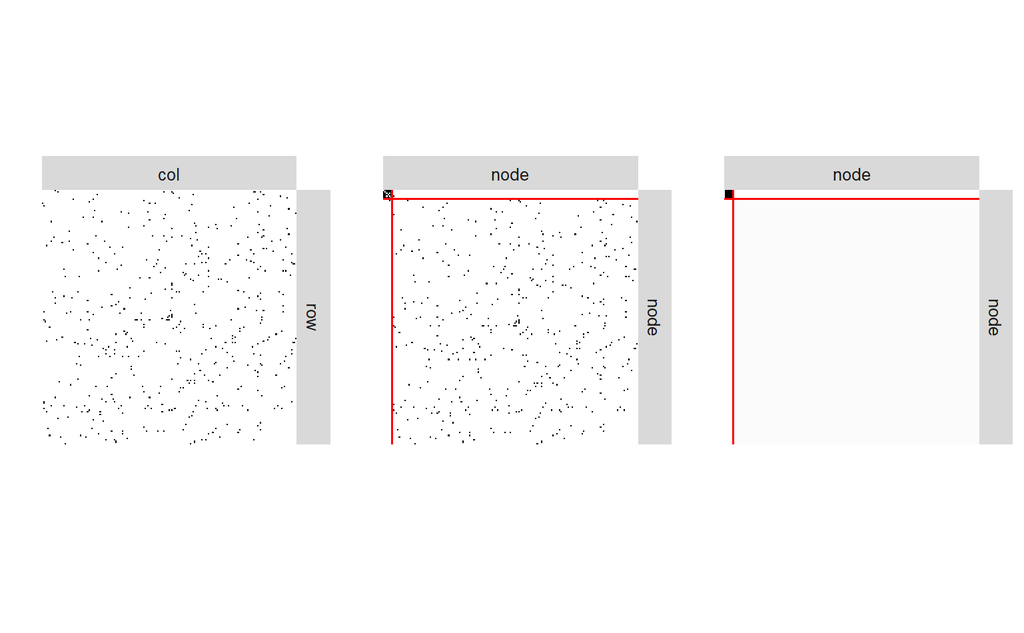

```r
plot1 <- ggdraw() + draw_plot({ plotMyMatrix(Yconn)})
plot2 <- ggdraw() + draw_plot({ plot(sbmConn,type="data")})
plot3 <- ggdraw() + draw_plot({ plot(sbmConn,"expected")})

# Combina i grafici in una griglia 1x3
plot_grid(plot1, plot2, plot3, nrow = 1)
```

## SBM su `marvel_Umaxconn` esteso

### Estensione degli archi nel grafo

Per poter valutare lo SBM in un contesto più ricco di connessioni tra i nodi, `marvel_Umaxconn` è stato esteso andando a recuperare per ogni personaggio relativo ai suoi **181 nodi** in quale fumetto avesse fatto la sua comparsa; ad esempio

| Personaggio | 1° Fumetto |
| --- | --- |
| Doctor Doom | Fantastic Four |
| Hulk | The Incredible Hulk |
| Iron Man | Tales of Suspense |
| Loki | Journey into Mystery |
| Magneto | The Uncanny X-Men |
| Thing | Fantastic Four |
| Thor | Journey into Mystery |

Queste informazioni poi sono state impiegate per creare dei **nuovi archi** per ogni coppia di **personaggi apparsi nella stessa collana**, a testimonianza di un probabile legame di **interazione debole.**

```r
library(readxl)
marvel_comics <- read_excel("marvel_comics.xlsx")
pid <- marvel_comics$id
for (n in 1:length(orig_char))
{
   pid[pid == orig_char[n]] = new_char[n]
}
pid = gsub("\\s*\\([^\\)]+\\)", "", pid)

seq_pid = match(V(marvel_Umaxconn)$name, pid)
pid = pid[seq_pid]
comics = as.factor(marvel_comics$comics[seq_pid])

score_comics <- table(comics)
comics_rank <- sort(score_comics, decreasing=T)
par(mar=c(9,4,2,0))
barplot(comics_rank,
        main = "Comics character ranking",
        xlab = "",
        ylab = "# characters",
        col='palegreen3', border='palegreen4',
        las = 2, # Etichette dell'asse x verticali
        cex.names = 0.5
)
grid(lty='solid', lwd=0.5, col='white', nx=NA, ny=NULL)
```

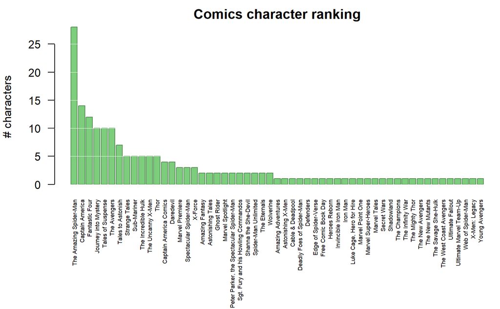

```r
par(mar=c(5,4,4,2)+0.1)
```

```r
# Estensione del grafo marvel_Umaxconn
V(marvel_Umaxconn)$comics = comics
Yext = 2*as_adjacency_matrix(marvel_Umaxconn, sparse=F)
for (i in 1:length(comics))
{
   pi = pid[i]
   for (j in 1:length(comics))
   {
      pj = pid[j]
      if (comics[i] == comics[j] && pi != pj)
      {
         #Yext[pi, pj] =  1
         #Yext[pj, pi] =  1

         if (Yext[pi, pj]==0)
         {
            Yext[pi, pj] = 1
            Yext[pj, pi] = 1
         }
      }
   }
}
marvel_Uext <- graph_from_adjacency_matrix(Yext, mode = 'undirected', weighted=T)
V(marvel_Uext)$comics = comics
V(marvel_Uext)$size = 3.5
V(marvel_Uext)$label.cex = 0.3
V(marvel_Uext)$label.family = 'sans'
V(marvel_Uext)$label.color='black'
E(marvel_Uext)$width = 0.6
E(marvel_Uext)$color = "gray"


color_comics <- rep("darkgray", length(comics_rank))
color_comics[1:6] = c('lightskyblue', 'sandybrown', 'yellowgreen', 'pink', 'gold3', 'plum3')
color_nodeByComics = rep("darkgray", vcount(marvel_Uext))
for (i in 1:vcount(marvel_Uext)) {
  com = V(marvel_Uext)$comics[i]
    id_com = which(names(comics_rank) == com)
    color_nodeByComics[i] = color_comics[id_com]
}
col_leg = c(color_comics[1:6], 'darkgray')
lab_leg = c(names(comics_rank)[1:6], 'others')

par(mar = c(0, 0, 0, 0)) #mfrow = c(1,2),
set.seed(myseed)
plot(marvel_Umaxconn,
     layout=layout_maxconn,
     vertex.frame.width = 0.5,
     vertex.color= color_nodeByComics,
     edge.width = 0.1,
)
legend("topright", legend=lab_leg, fill=col_leg, title='Comics', bty='n', cex=0.6)
```

[figure not shown]

```r
par(mar=c(5,4,4,2)+0.1)

color_edge = rep("lightgray", length(E(marvel_Uext)$weight))
idstrong = which(E(marvel_Uext)$weight>1)
color_edge[idstrong] = 'black'

par(mar = c(0, 0, 0, 0))
```

```r
set.seed(myseed)
plot(marvel_Uext,
     layout=layout_maxconn,
     vertex.frame.width = 0.5,
     vertex.color= color_nodeByComics,#V(marvel_Uext)$comics,
     edge.width = 0.1*E(marvel_Uext)$weight,
     edge.color = color_edge#E(marvel_Uext)$weight,
)
legend("topright", legend=lab_leg, fill=col_leg, title='Comics', bty='n', cex=0.6)
```

[figure not shown]

```r
par(mar=c(5,4,4,2)+0.1) #mfrow = c(1,1),
```

### Applicazione dello SBM

#### Versione binarizzata (Bernoulli)

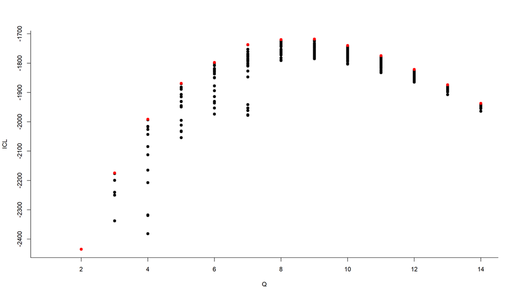

Selezione del # Q di blocchi latenti tramite ICL

```r
library(colorspace)

Yext_binary <- ifelse(Yext > 0.5, 1, 0)
sbm = estimateSimpleSBM(Yext_binary, 'bernoulli', estimOptions=list(verbosity=0))
```

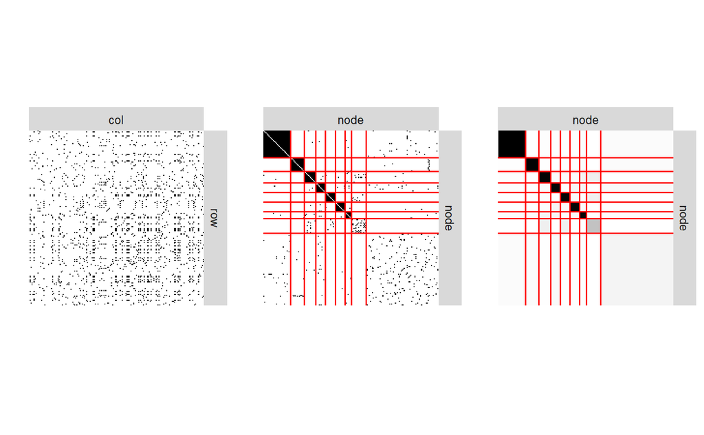

```r
plot1 <- ggdraw() + draw_plot({ plotMyMatrix(Yext_binary) })
plot2 <- ggdraw() + draw_plot({ plot(sbm, type = "data") })
plot3 <- ggdraw() + draw_plot({ plot(sbm, "expected") })

plot_grid(plot1, plot2, plot3, nrow = 1)
```

Nella figura superiore, da sinistra verso destra: la matrice di adiacenza binaria in ingresso, la matrice organizzata in blocchi e la sua versione in termini di probabilità (che rivedremo anche dopo).

```r
(sbm$blockProp)
```

```
[1] 0.15448025 0.07751530 0.06652031 0.05552532 0.05552532 0.05552532 0.03903283
[8] 0.08301217 0.41286318
```

```r
par(mar=c(4,4,3,0))
barplot(sbm$blockProp,
        main = "sbm$blockProp",
        xlab = "blocks",
        ylab = "prob.",
        col='palegreen3', border='palegreen4',
        # las = 2,
        cex.names = 1,
        names.arg = 1:length(sbm$blockProp)
)
grid(lty='solid', lwd=0.5, col='white', nx=NA, ny=NULL)
```

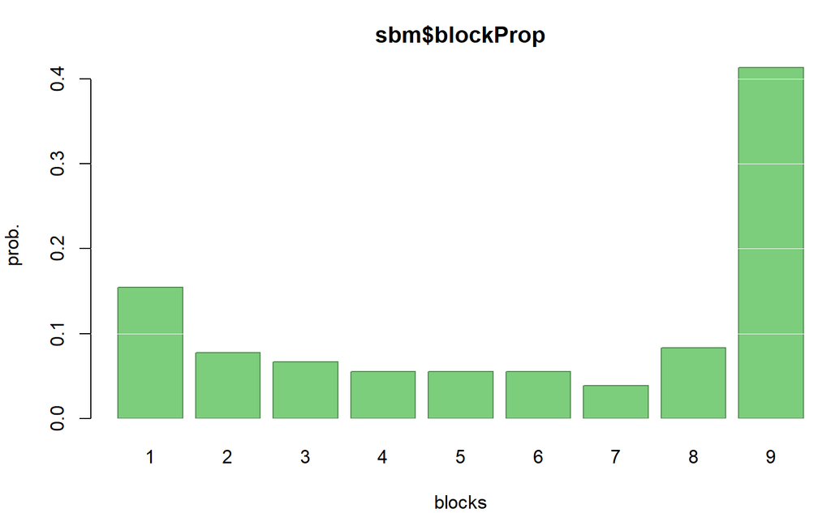

```r
par(mar=c(5,4,4,2)+0.1)
```

Sopra, le **probabilità *a priori* di appartenza dei vari nodi ai diversi blocchi.**

```r
# connectivity parameters
(round(sbm$connectParam$mean,3))
```

```
       [,1]  [,2]  [,3]  [,4]  [,5]  [,6]  [,7]  [,8]  [,9]
 [1,] 0.994 0.001 0.007 0.005 0.002 0.002 0.012 0.001 0.015
 [2,] 0.001 0.986 0.001 0.001 0.001 0.001 0.011 0.001 0.013
 [3,] 0.007 0.001 0.983 0.018 0.009 0.009 0.036 0.055 0.004
 [4,] 0.005 0.001 0.018 0.980 0.001 0.031 0.029 0.001 0.021
 [5,] 0.002 0.001 0.009 0.001 0.979 0.021 0.001 0.053 0.000
 [6,] 0.002 0.001 0.009 0.031 0.021 0.979 0.015 0.001 0.003
 [7,] 0.012 0.011 0.036 0.029 0.001 0.015 0.969 0.001 0.008
 [8,] 0.001 0.001 0.055 0.001 0.053 0.001 0.001 0.216 0.000
 [9,] 0.015 0.013 0.004 0.021 0.000 0.003 0.008 0.000 0.039
```

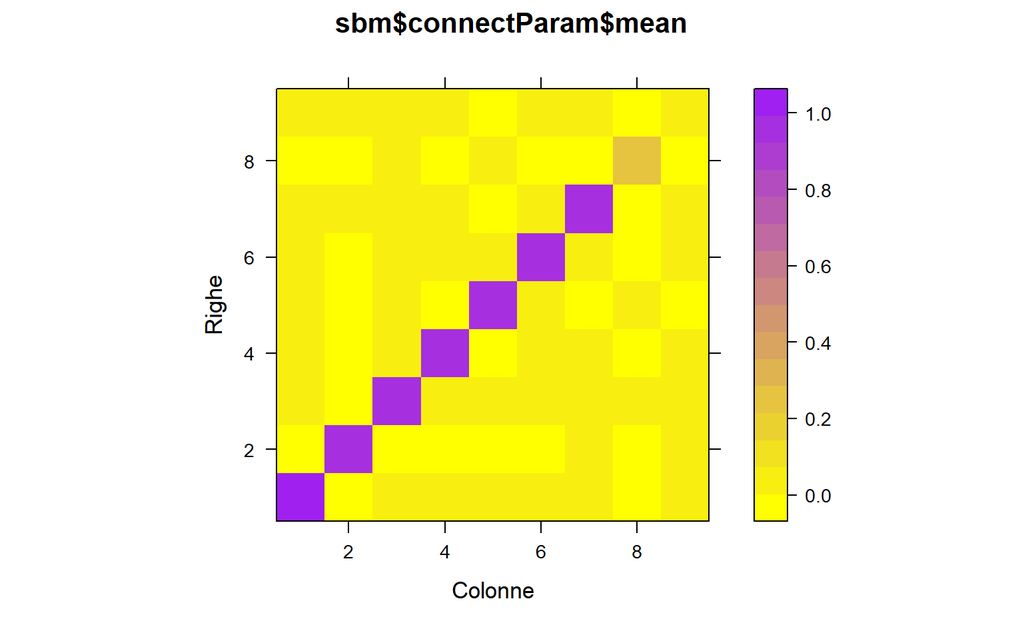

```r
levelplot(sbm$connectParam$mean,
          col.regions = colorRampPalette(c("yellow", "purple"))(100),
          main = 'sbm$connectParam$mean',
          xlab = "Colonne", ylab = "Righe")
```

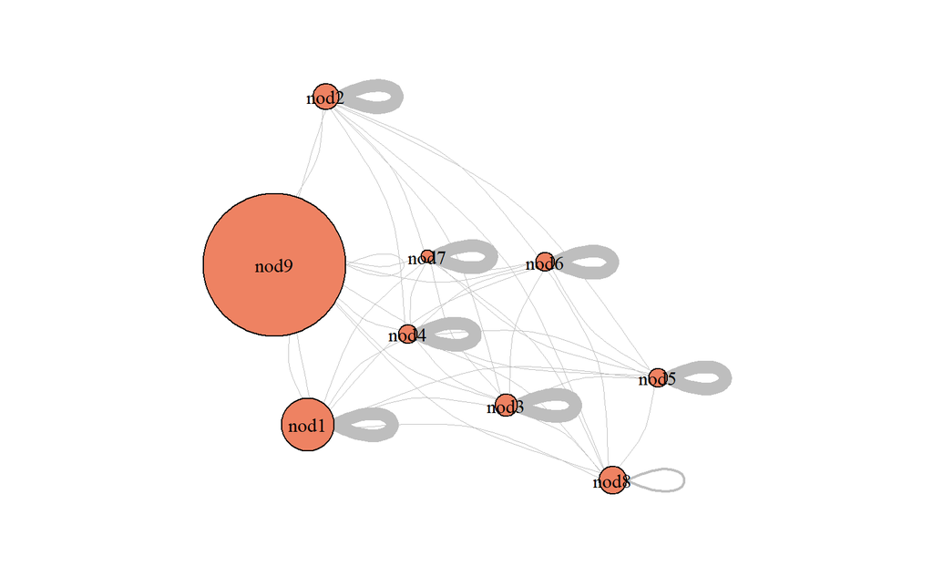

```r
set.seed(myseed)
par(mar=c(0,0,0,0))
plot(sbm, type = "meso")
par(mar=c(5,4,4,2)+0.1)
```

Sopra, la rappresentazione in forma *mesoscopica* della matrice precedente:

- ogni nodo indica un blocco, di dimensioni proporzionali al # di nodi allocati in ognuno di essi
- lo spessore degli archi è proporzionale alle probabilità di creare archi tra nodi di blocchi diversi (o dello stesso blocco, per gli archi *self loop*)

#### Assegnamento dei nodi per blocco

```r
color_blocks = rep("darkgray", length(sbm$memberships))
color_blocks[1:8] = c('dodgerblue2', 'orange', 'limegreen', 'pink', 'gold4', 'mediumorchid', 'gold', 'firebrick')

block_rank = sort(sbm$memberships, decreasing=T)
color_nodeByBlocks = rep("darkgray", vcount(marvel_Uext))
for (i in 1:vcount(marvel_Uext))
{
   id_com = sbm$memberships[i]
   color_nodeByBlocks[i] = color_blocks[id_com]
}
col_leg = c(color_blocks[1:9])
lab_leg = c(1:9)
#lab_leg <- c(names(color_blocks)[1:8], '>8')

par(mar=c(0,0,0,0))
plot(marvel_Uext,
     layout=layout_maxconn,
     vertex.frame.width = 0.5,
     vertex.color= color_nodeByBlocks,#sbm$memberships,
     edge.width = 0.1,
)
legend("topright", legend=lab_leg, fill=col_leg, title='Blocks', bty='n', cex=0.6)
```

[figure not shown]

```r
par(mar=c(5,4,4,2)+0.1)
```

[figure not shown]

Confronto tra comics e blocchi

```r
id7 = which(sbm$memberships==7)
tab7 = data.frame(Personaggio = V(marvel_Uext)$name[id7], Fumetto = V(marvel_Uext)$comics[id7])
(tab7)
```

| Personaggio | Fumetto |
| --- | --- |
| Wasp | Tales to Astonish |
| Abomination | Tales to Astonish |
| Egghead | Tales to Astonish |
| Leader | Tales to Astonish |
| Porcupine | Tales to Astonish |
| Hank Pym | Tales to Astonish |
| Boomerang | Tales to Astonish |

```r
id8 = which(sbm$memberships==8)
tab8 = data.frame(Personaggio = V(marvel_Uext)$name[id8], Fumetto = V(marvel_Uext)$comics[id8])
(tab8)
```

| Personaggio | Fumetto |
| --- | --- |
| Malekith the Accursed | Thor |
| Mercurio the 4-D Man | Thor |
| Kro | The Eternals |
| Titania | Secret Wars |
| Llyra | Sub-Mariner |
| Ulik | Thor |
| Kurse | Thor |
| Lemuel Dorcas | Sub-Mariner |
| Lorelei | The Mighty Thor |
| Tiger Shark | Sub-Mariner |

[output cut: 5 more lines]

#### Probabilità a posteriori di assegnazione di un nodo ai vari blocchi

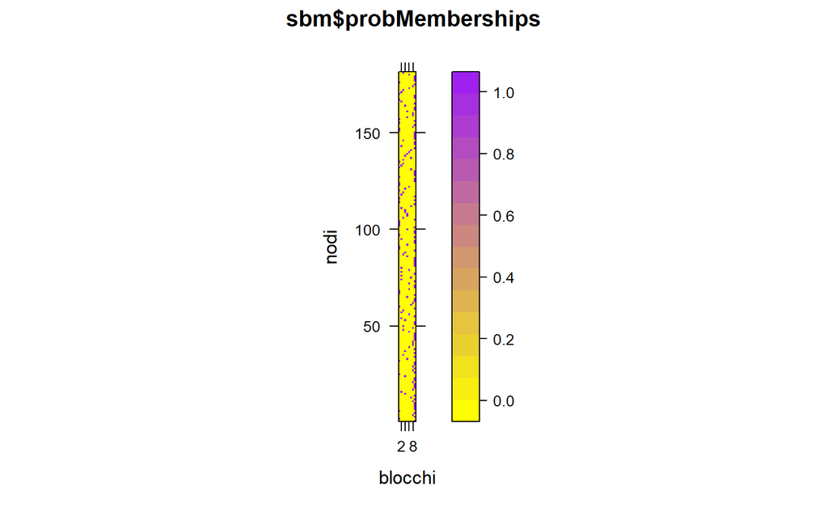

```r
levelplot(t(sbm$probMemberships),
          col.regions = colorRampPalette(c("yellow", "purple"))(100),
          main = 'sbm$probMemberships',
          xlab = "blocchi", ylab = "nodi")
```

```r
# sbm = estimateSimpleSBM(Yext, 'poisson', estimOptions=list(verbosity=0))
#
# plot1 <- ggdraw() + draw_plot({ plotMyMatrix(Yext) })
# plot2 <- ggdraw() + draw_plot({ plot(sbm, type = "data") })
# plot3 <- ggdraw() + draw_plot({ plot(sbm, "expected") })
#
# plot_grid(plot1, plot2, plot3, nrow = 1)
#
# block_rank = sort(sbm$memberships, decreasing=T)
# color_nodeByBlocks = rep("darkgray", vcount(marvel_Uext))
# for (i in 1:vcount(marvel_Uext))
# {
#    blk = sbm$memberships[i]
#    id_com <- which(block_rank == blk)
#    color_nodeByBlocks[i] = color_blocks[id_com[1]]
# }
# col_leg = c(color_blocks[1:8], 'darkgray')
# lab_leg <- c(names(color_blocks)[1:8], '>8')
#
# par(mar=c(0,0,0,0))
# plot(marvel_Uext,
#      layout=layout_maxconn,
#      vertex.frame.width = 0.5,
#      vertex.color= sbm$memberships,
#      edge.width = 0.1,
#      edge.color = color_edge,
# )
# par(mar=c(5,4,4,2)+0.1)
#
# (sbm$blockProp)
# par(mar=c(4,4,3,0))
# barplot(sbm$blockProp,
#         main = "sbm$blockProp",
#         xlab = "blocks",
#         ylab = "prob.",
#         col='palegreen3', border='palegreen4',
#         # las = 2,
#         cex.names = 1,
#         names.arg = 1:length(sbm$blockProp)
# )
# grid(lty='solid', lwd=0.5, col='white', nx=NA, ny=NULL)
# par(mar=c(5,4,4,2)+0.1)
#
# # connectivity parameters
# (round(sbm$connectParam$mean,3))
# levelplot(sbm$connectParam$mean,
#           col.regions = colorRampPalette(c("yellow", "purple"))(100),
#           main = 'sbm$connectParam$mean',
#           xlab = "Colonne", ylab = "Righe")
#
# set.seed(myseed)
# par(mar=c(0,0,0,0))
# plot(sbm, type = "meso")
# par(mar=c(5,4,4,2)+0.1)
```